# Tuolumne River

Sadie Gill, Mark Tompkins, Erin Cain

June 6, 2019

## Future Data Improvement

Instream habitat suitability relationships provided for the Voluntary Agreement process.

## Instream Spawning and Rearing Habitat

**Data Source:** [Final Lower Tuolumne Instream Flow Study Report](https://s3-us-west-2.amazonaws.com/cvpiahabitat-r-package/cvpia-sit-model-inputs/Stillwater2010_Tuolumne_P-2299-075_71_DP_FLA_AttC_StudyRept_IFIM_AppA-H_140428.pdf) (pg. 108-109)

Instream spawning and rearing habitat for Fall Run Chinook Salmon and Steelhead in the Tuolumne River is based on data from a California Department of Fish and Game site specific study. This data consists of 10 sites spread over 9.2 miles of the dominant spawning reach of the Lower Tuolumne River and was reviewed by Stillwater Sciences for use in their 2014 Flo2D model. THe WUA results for Salmon and Steelhead are provided in tables H-1 and H-2 on pgs 108-109 of Final Lower Tuolumne Instream Flow Study Report. The instream spawning and rearing habitat data was provided to us by Mark Gard from the U.S. Fish and Wildlife Service in a spreadsheet (see ‘~/cvpiaHabitat/data-raw/mark_gard_data/IFIMWUA.xlsx’). Mark Gard instructed us to use cells A2:H32 in the ‘Tuolumne’ tab within his ‘IFIMWUA.xlsx’.

### Combine Spawning and Rearing Data

The instream spawning and rearing habitat data described above for Fall Run Chinook Salmon (FR) and Steelhead (ST) is combined for use in the DSM in the following format. Units are in square feet per 1000 feet.

| flow_cfs | FR_spawn_wua | FR_fry_wua | FR_juv_wua | ST_spawn_wua | ST_fry_wua | ST_juv_wua | ST_adult_wua | watershed |
| --- | --- | --- | --- | --- | --- | --- | --- | --- |
| 50 | 2116.32 | 32897.03 | 48648.28 | 11648.21 | 54751.06 | 53029.98 | 15204.23 | Tuolumne River |
| 75 | 4950.27 | 30762.01 | 50596.55 | 17137.87 | 50438.41 | 55934.07 | 20427.83 | Tuolumne River |
| 100 | 7447.46 | 28799.02 | 51759.16 | 21449.10 | 46884.87 | 57493.70 | 24811.70 | Tuolumne River |
| 125 | 10807.84 | 27025.69 | 52516.33 | 24938.94 | 44259.05 | 58459.15 | 28513.29 | Tuolumne River |
| 150 | 13071.88 | 25415.04 | 52814.11 | 27813.79 | 42362.45 | 58803.13 | 31455.03 | Tuolumne River |

###### … with 25 more rows.

### Spawning WUA

The instream spawning habitat weighted usable areas for Fall Run Chinook Salmon and Steelhead in the Tuolumne River.

#### Chinook Salmon Spawning WUA Plot

The following plot shows the weighted usable spawning area in square feet per thousand feet of river for Fall Run Chinook Salmon. These area per length rates are multiplied by the total spawning reach length mapped by the SIT.

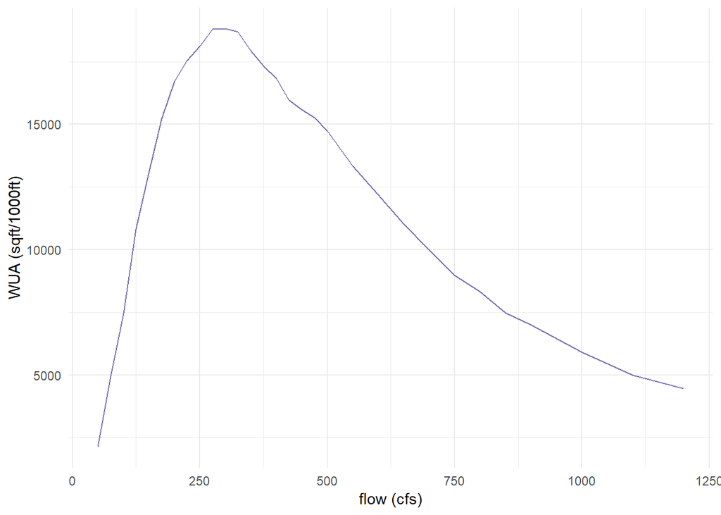

#### Steelhead Spawning WUA Plot

The following plot shows the weighted usable spawning area in square feet per thousand feet of river for Steelhead. These area per length rates are multiplied by the total spawning reach length mapped by the SIT.

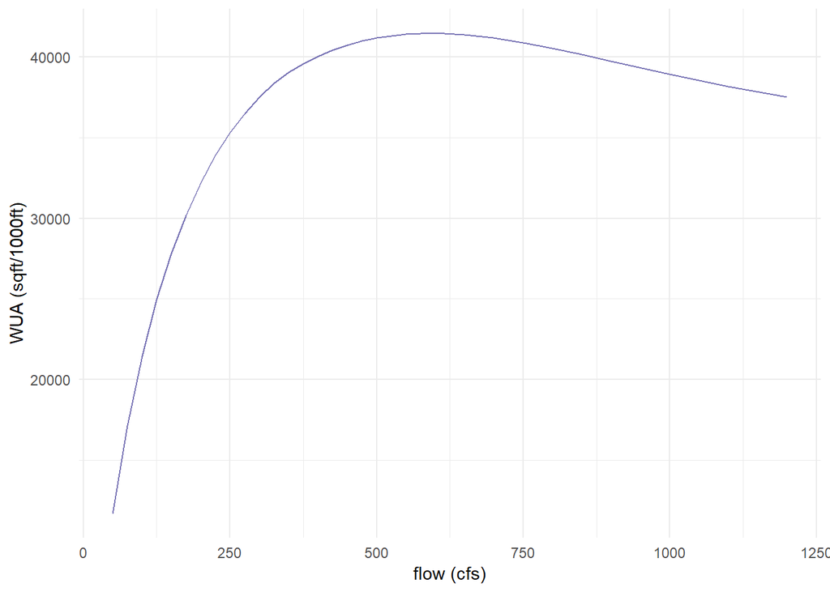

### Rearing WUA

The fry and juvenile instream rearing habitat weighted usable areas for Fall Run Chinook Salmon and Steelhead in the Tuolumne River.

#### Chinook Salmon Rearing WUA Plot

The following plot shows the weighted usable rearing area in square feet per thousand feet of river for Fall Run Chinook Salmon fry and juvenile. These rates are multiplied by the total rearing reach length mapped by the SIT.

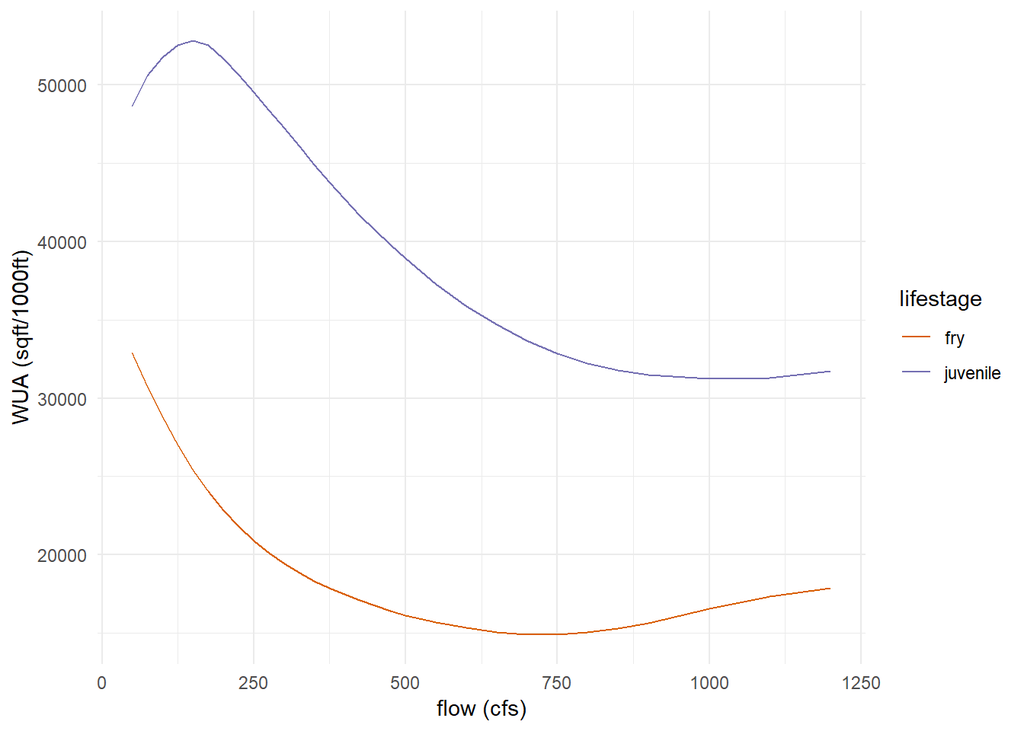

#### Steelhead Rearing WUA Plot

The following plot shows the weighted usable rearing area in square feet per thousand feet of river for Steelhead fry and juvenile. These rates are multiplied by the total rearing reach length mapped by the SIT.

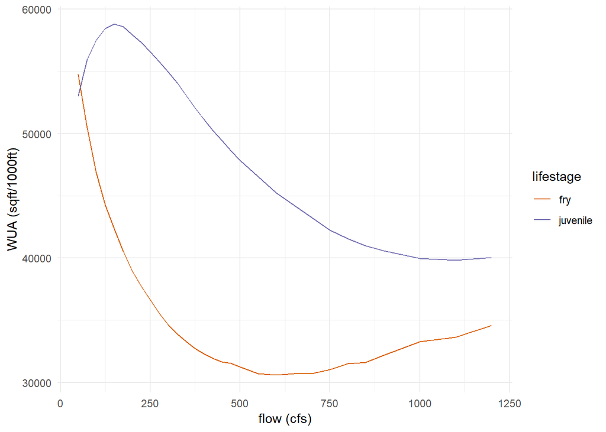